# THE EFFECTS OF COVID-19 ON THE TOPICS OF DEPRESSION SUBREDDIT POSTS IN ENGLISH

Mira Luna Leenders and Serkan Shentyurk

2023-09-01

# Introduction

Mental health is one of the main pillars of health, as it is stated in WHO’s proposition: “There is no health without mental health.” (WHO, 2005). It is not only the crucial element of the health, but also the mental disorders correspond to the 20% of disease burden in 2005 and predicted it to correspond to 20% in 2030 (Mathers and Loncar, 2006). Mental disorders are shown to have not just psychological, but physical effects as well: The onset of physical and social disability can be linked with depression (Bruce et al., 1994) and it is shown that 69% of the cases of disability are due to the mental disorders (Prince et al., 1998). WHO’s estimates suggest that neuropsychiatric diseases are responsible of 1.2 million deaths per year and the mental disorders corresponds to 40,000 (Mathers and Loncar, 2006). However, these numbers high likely underestimate and should be taken with a pinch of salt, since suicides and excess use of drugs and alcohol are not affiliated with mental disorders in this report, even though there is a clear relationship between them (Lynch et al., 2020).

It is clear that mental and psychiatric disorders are not less prevalent than other diseases - such as cancer, infectious diseases), however, they are not as prioritise as them especially in low-income countries. Low and middle-income countries mainly focus on containment of infectious disease whereas high-income countires focus on cardio-vascular diseases and cance. Even though there are distinct departments for mental health disease in some countries, the budget, service, and personnel are fairly limited (Prince et al., 2007). In addition to the limited services, there are additional barriers that block accessing the mental health care providers. The stigma of having a pyschiatric disorder or the stigma of seing a psychologist and/or psychiatrist still prevail and this drastically reduces the rate of seeking psychological help (Brown et al., 2016). Social media provides some solutions to these problems: Anonymity, no cost, easy to access (De Choudhury and De, 2014). These provides users to stay anonymous - hence, avoid stigmatization - and the opportunity of seeking help without the economic burden.

COVID-19 is decleared as a new outbreak in January 2020 and charactarised as a pandemic in March 2020 (WHO, 2020). The governments around the globe acted to prevent the spread of the disease and contain it. This changes of priority and the actions taken to tackle the crises - especially lockdowns and quarantines - affected the mental health drastically (Fiorillo and Gorwood, 2020). Quarantine and contaminants methods are linked with various psychological stressors. Since the precedence of the law makers was the containment of the COVID-19, the mental health was not prioritised not only in the middle and low income countries, but in high-income countries as well (Purssell et al., 2020). We assumed that the increase stress due to the pandemic and the reduce accessibility to the mental health care providers can lead people to use social media sites to share their problems, practices, and talk with other people who confronts similar problems. To investigate our assumption, we formulated our research question and sub-questions:

**Research Question:** Does COVID-19 have an effect on the topic frequency of the topics of the ‘Depression’ Subreddit Posts in English?

**Sub-questions:**

- How many main topics can the post be divided into?
- Have the frequency of topics changed before and after COVID-19 pandemic started?
- Have the frequency of topics changed through-out the pandemic?

# Methods - Research Design

## Data Gathering

Data contains following attributes for each post: clicked, created_utc, date, distinguished, edited, id, is_original_content, is_text_only, link_flari_template_id, link_flair_text, locked, name, num_comments, over_18, permalink, score, body, spoiler, stickied, subreddit_id, subreddit_name, title, upvote_ratio, and url. We were mainly interested in date and body - which contains the content of the post. It is important to note that the dataset contains the post only from 2009 to January 2021. Considering the fact that COVID-19 measurements last throughout not just 2020 but 2021 as well, we cannot capture middle-term effects of the COVID-19 on Reddit depression and mental health submissions. Another limitation is that we cannot research the post-COVID-19 era because of the same reasons.

Nevertheless, despite these important limitations, we still consider that it should be interesting to analyse whether the topics of posts in English at Depression subreddit are affected by COVID-19.

When we wanted to load our data, we encountered a problem in R. Due to the size and format of the file, there was a memory issue and RStudio shut itself down. To handle this problem, we first arranged the file in Python - which handled the memory issue without problem -, then used R.

### Data Gathering: Python

First we loaded the libraries in Python.

```r
# import pandas as pd
# import json
# from datetime import datetime
```

Then, we created 2 classes and attributes to handle single post and multiple posts, loaded our data using these classes, created a dataframe and added ‘Year’ column. Finally we exported our data in json format that we can use in R.

```r
# class post:
#    def __init__(self, json_file):
#        self.date = datetime.strptime(json_file['date'], '%Y-%m-%d %H:%M:%S')
#        self.is_text_only = json_file['is_text_only']
#        self.title = json_file['title']
#        self.text = json_file['body']
#        self.url = json_file['url']
# class multiple_posts:
#    def __init__(self):
#        self.data = np.array([0,0,0]).reshape(1,3)
#    def add(self, post_obj):
#        date = datetime(post_obj.date.year, post_obj.date.month, 1)
# self.data = np.append(self.data, np.array([date,
#                       post_obj.title, post_obj.text]).reshape(1,3), axis = 0)
#    def remove_place_holder(self):
#        self.data = self.data[1:]
#    def sort_by_date(self):
#        index = np.argsort(self.data[:,0])
#        self.data = self.data[index]
#
# # Load Data
# json_path = '_reddit-posts-gatherer-en.submissions_subset.json'
# f = open(json_path)
# all_data = json.load(f)
# f.close()
#
# # Multiple Posts object
# data = multiple_posts()
#
# # Create Post object and add to Multiple Posts object
# for item in all_data:
#    data.add(post(item))
#
# # Remove the initial place holder, sort data by date, create df, change column names, # drop NAs, and add Year column
# data.remove_place_holder()
# data.sort_by_date()
# df = pd.DataFrame(data.data, columns=['Date', 'Title', 'Text'])
# df = df.dropna() # Some deleted posts were still in the data and appeared as NA.
# df['Year'] = df['Date'].dt.year
# df.to_json(r'/Users/Serkan/Academa/2022-2023/2023 Spring/Collecting and Analyzing Big Data for Social Sciences/Project/Q3/reddit_data_updated.json')
```

### Data Gathering: R

We loaded required libraries in R and create handle_contractions function that we will use later to correct contractions.

```r
set.seed(0)
# Libraries
library(jsonlite)
library(stringr)
library(tm)
library(tidytext)
library(topicmodels)
library(ggplot2)
library(dplyr)
library(tidyr)
library(reshape2)
library(lubridate)
library(png)

# Function to handle contractions
handle_contractions <- function(text) {
  contractions <- c("i'm" = "i am","i've" = "i have","i'll" = "i will","i'd" = "i would",
    "you're" = "you are","you've" = "you have","you'll" = "you will","you'd" = "you would",
    "he's" = "he is","he'd" = "he would","she's" = "she is","she'd" = "she would","it's" = "it is",
    "it'd" = "it would","we're" = "we are","we've" = "we have","we'll" = "we will","we'd" = "we would",
    "they're" = "they are","they've" = "they have","they'll" = "they will","they'd" = "they would",
    "can't" = "cannot","won't" = "will not","don't" = "do not","doesn't" = "does not",
    "didn't" = "did not","shouldn't" = "should not","wouldn't" = "would not","isn't" = "is not",
    "aren't" = "are not","wasn't" = "was not","weren't" = "were not","hasn't" = "has not",
    "haven't" = "have not","hadn't" = "had not","doesn't" = "does not","couldn't" = "could not")
    for (contraction in names(contractions)) {
      text <- gsub(contraction, contractions[contraction], text)
    }
    return(text)
}
```

We loaded our data and created dataframe df containing title, year, text, and date. The data was stored as integer, we changed the format and stored in the dataframe.

```r
# Load the package required to read JSON files.
set.seed(0)
path = '/Users/Serkan/Desktop/Academia/KUL/2022 - 2023/2023 Spring/Collecting and Analyzing Big Data for Social Sciences/Project/Q3'
setwd(path)
file = 'reddit_data_updated.json'
data <- fromJSON(file)

# Create a new dataframe with a single column
df <- data.frame(date_int = unlist(data$Date),
                 title = unlist(data$Title),
                 year = unlist(data$Year),
                 text = unlist(data$Text))

df$date_formatted = as.POSIXct(df$date_int / 1000, origin = "1970-01-01")

# Format the date as "YYYY-MM-DD" strings
df$date = format(df$date_formatted, "%Y-%m-%d")
```

## Data Filtering and Data Cleaning

We decided not to conduct any data filtering steps, simply because the aim of the project is determine the existing topics in an unsupervised learning fashion. Additionally, the data are obtained from specifically Depression subreddit, hence, a hypothetical filter is already applied and any further filtering would require field knowledge, which we do heavily lack.

Before starting any analysis, we wanted to clean our data and make it ready for the analysis. We lowered the text, handled contractions, removed any HTML tags, removed numbers, replaced newline ‘’ with space, removed stopwords, removed punctuations, removed extra spaces, trimmed the data, added a place holder word, and, finally, tokenized the data. The place holder word was added to be able to run LDA function in further analysis, otherwise we received empty vector errors - even though none of the texts are empty and/or NA.

```r
set.seed(0)
df$text_clean = tolower(df$text)                          # Lowers text
df$text_clean = handle_contractions(df$text_clean)        # Handle contractions
df$text_clean = gsub("<.*?>", "", df$text_clean)          # Remove HTML tags
df$text_clean = gsub("[0-9]+", "", df$text_clean)          # Remove Numbers
df$text_clean =  gsub("\n|-", " ", df$text_clean)            # Replace newline with space
df$text_clean = removeWords(df$text_clean, stopwords("en")) # Remove stopwords
df$text_clean = gsub("[[:punct:]]", " ", df$text_clean) # Remove punctuations
df$text_clean = gsub("[[:space:]]+", " ", df$text_clean)  # Remove extra spaces
df$text_clean = str_trim(df$text_clean)
df$text_clean = paste(df$text_clean, ' place_holder_for_analysis')
tokens = df %>% unnest_tokens(word, text_clean) # Tokenizing
```

An example of data before cleaning:

```r
df$text[1]
```

```
## [1] "On and off from 08-09 I'd undergo changes in my sleeping, behavioral and eating patterns. I'd be happy, then sad suddenly, followed by a short, contained, burst of anger. Once it got so bad that I felt nothing, and that I just didn't want to live anymore.\n\nI'm posting here because I'd like…
```

and after cleaning:

```r
df$text_clean[1]
```

```
## [1] "undergo changes sleeping behavioral eating patterns happy sad suddenly followed short contained burst anger got bad felt nothing just want live anymore posting like hear fellow redditors think situation can anything wrong girlfriend friends suggest may depressed know whether agree disagree e…
```

## LDA Model

We decided to use Latent Dirichlet Analysis (LDA) for topic modelling. LDA is proven to be useful to determine the topics of given text data (Blei et al., 2003) and has been used for similar analysis of Reddit posts before (Low et al., 2020).

First, we wanted to create a corpus of our data. In LDA, the most frequent words or words don’t have particular meaning might appear in all data points and reduce the performance of the model. Hence, we listed the terms that have frequency higher than 10000 - based on our data, so that we remove 40-50 most frequent words - and removed them from our corpus.

```r
set.seed(0)
corpus = Corpus(VectorSource(df$text_clean))
document_term_matrix = DocumentTermMatrix(corpus)

# Most frequent terms
freq_terms <- findFreqTerms(document_term_matrix, lowfreq = 10000)
print(freq_terms)
```

```
##  [1] "anything"                  "can"
##  [3] "friends"                   "got"
##  [5] "just"                      "know"
##  [7] "like"                      "place_holder_for_analysis"
##  [9] "think"                     "want"
## [11] "even"                      "feel"
## [13] "going"                     "life"
## [15] "make"                      "people"
## [17] "still"                     "time"
## [19] "one"                       "work"
## [21] "back"                      "better"
## [23] "day"                       "depression"
## [25] "get"                       "good"
## [27] "much"                      "never"
## [29] "now"                       "really"
## [31] "school"                    "something"
## [33] "things"                    "way"
## [35] "will"                      "help"
## [37] "see"                       "someone"
## [39] "years"                     "always"
## [41] "everything"                "year"
```

```r
# Words to remove
words_to_remove = c('can', 'friends', 'got', 'just', 'know', 'like', 'think', 'want', 'even',
                    'feel', 'going', 'life', 'make', 'people', 'still', 'time', 'one', 'work', 'back',
                    'better', 'day', 'depression', 'get', 'good', 'much', 'never', 'now', 'really',
                    'school', 'something', 'things', 'way', 'will', 'help', 'see', 'someone', 'years',
                    'always', 'everything', 'year')
# Remove the words
df$text_clean = removeWords(df$text_clean, words_to_remove)
# Recreate the corpus
corpus = Corpus(VectorSource(df$text_clean))
document_term_matrix = DocumentTermMatrix(corpus)
```

### LDA Model: Determining the Number of Topics

Before creating the LDA model, we had to determine the number of topics within the data. To determine the number of topics, we wanted to used coherence score and took the number whose coherence score do not change much when the number of topics increased. However, at this step we again encountered with memory problem. To encounter the problem and obtain the optimum number of topics, we applied the test in Python and plotted the coherence score against number of topics (for Python scripts, see Appendix). We selected 4 as the number of topic.

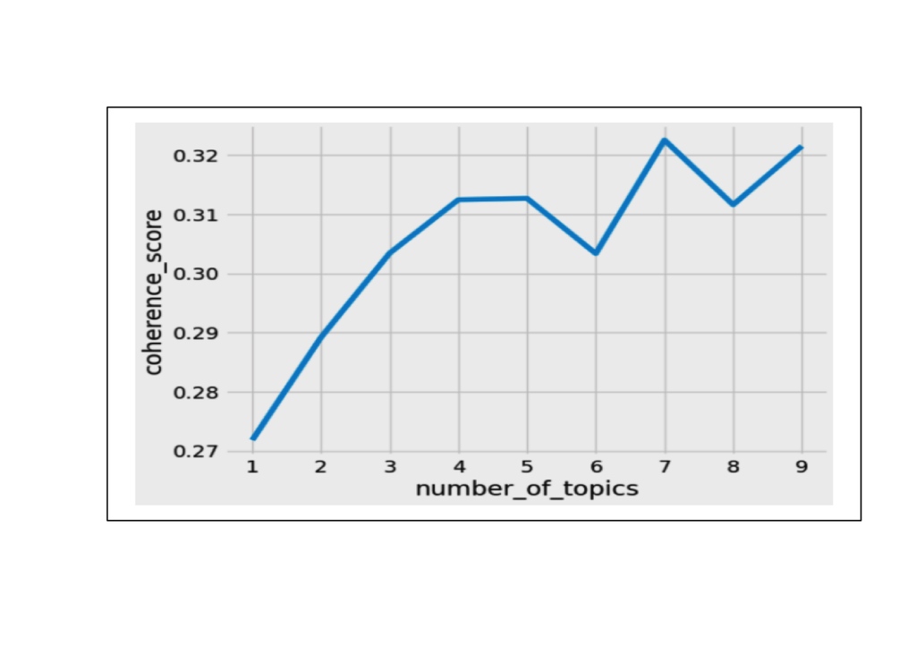

```r
image_path <- "/Users/Serkan/Desktop/Academia/KUL/2022 - 2023/2023 Spring/Collecting and Analyzing Big Data for Social Sciences/Project/Q3/images/plot_coherence.png"
img <- readPNG(image_path)
# Display the image
plot(0:1, 0:1, type = "n", xlab = "", ylab = "", xaxt = "n", yaxt = "n")
rasterImage(img, 0, 0, 1, 1)
```

### LDA Model: Fitting the Model

We trained LDA model and listed the words for each topic using the number of topics determined before and chunk of 10 words.

```r
number_topics = 4
chunk = 10
set.seed(0)
LDA_model = LDA(document_term_matrix,control=list(seed=0), k = number_topics)
top_terms = terms(LDA_model, chunk)

top_terms
```

```
##       Topic 1     Topic 2                     Topic 3
##  [1,] "anything"  "anyone"                    "place_holder_for_analysis"
##  [2,] "last"      "right"                     "also"
##  [3,] "sometimes" "place_holder_for_analysis" "job"
##  [4,] "nothing"   "months"                    "anything"
##  [5,] "felt"      "well"                      "long"
##  [6,] "talk"      "find"                      "trying"
##  [7,] "person"    "everyone"                  "first"
##  [8,] "ever"      "need"                      "anymore"
##  [9,] "depressed" "feeling"                   "shit"
## [10,] "keep"      "around"                    "try"
##       Topic 4
##  [1,] "started"
##  [2,] "made"
##  [3,] "feeling"
##  [4,] "home"
##  [5,] "need"
##  [6,] "anything"
##  [7,] "every"
##  [8,] "nothing"
##  [9,] "friend"
## [10,] "long"
```

LDA analysis does not provide topic labels, only the words that are contained within the topics. We interpreted the potential names for each topic based on the words the topic contains.

Topic 1 - Personal & Emotional Well-Being: The topic contains the words ‘anything’, ‘last’, ‘sometimes’, ‘nothing’, ‘felt’, ‘talk’, ‘person’, ‘ever’, ‘depressed’, ‘keep’. Hence, we inferred that the topic revolves around emotional and personal experiences.

Topic 2: Relationship & Interactions - The topic contains the words ‘Anyone’, ‘right’, ‘months’, ‘well’, ‘find’, ‘everyone’, ‘need’, ‘feeling’, ‘around’. Hence, we inferred that topic is centered on relationships, interactions, and connections.

Topic 3: Job & Career: The topic contains the words ‘also’, ‘job’, ‘anything’, ‘long’, ‘trying’, ‘first’, ‘anymore’, ‘shit’, ‘try’. The keywords are somewhat ambiguous, however, since it is the only topic that contains job-related words, we labeled the group as ‘Job & Career’.

Topic 4: Communication & Thoughts: The topic contains the words ‘started’, ‘made’, ‘feeling’, ‘home’, ‘need’, ‘anything’, ‘every’, ‘nothing’, ‘friend’, ‘long’. The keywords are ambiguous, again, they are related to various topics, some of which are also covered by the other topics. When asked to ChatGPT, it suggested the topic ‘Personal Development’ due to the fact that the words revolves around home, belonging, personal achievements.

We calculated the posterior probabilities of each text, selected the most probable topic as topic and assigned it as a new column.

```r
# Get posterior probabilities for each document-topic combination
topic_posteriors <- posterior(LDA_model)$topics

# Find the most likely topic for each document
most_likely_topics <- apply(topic_posteriors, 1, function(row) {
  most_likely_topic <- which.max(row)
  return(most_likely_topic)
})

df$topics = most_likely_topics
```

# Results

## Analysis over the Years

We wanted to check the number of topics per each year. We can see that all years except 2009, 2010, and 2021 contains 3000 texts. Considering we have only January data in 2021 and Reddit’s popularity increased drastically in 2011 (Martin, 2012), we decided to exclude years 2009, 2010, and 2021.

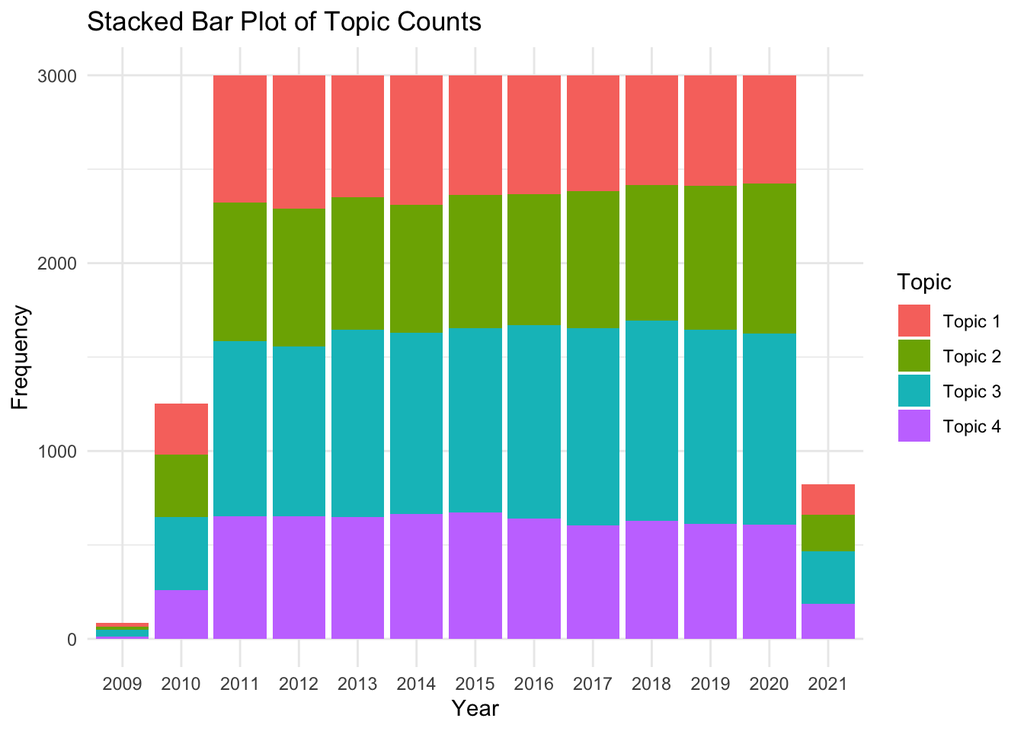

```r
# Counts
freq_table = table(df$year, df$topics)
freq_data <- as.data.frame(freq_table)
colnames(freq_data) <- c("Year", "Topic", "Frequency")

# Plot Count for all
ggplot(freq_data, aes(x = Year, y = Frequency, fill = factor(Topic))) +
  geom_bar(stat = "identity") +
  labs(title = "Stacked Bar Plot of Topic Counts",
       x = "Year",
       y = "Frequency") +
  scale_fill_discrete(name = "Topic", labels = c("Topic 1", "Topic 2", "Topic 3", "Topic 4")) +
  theme_minimal()
```

We kept the years 2011 to 2020 and plotted the count and frequencies.

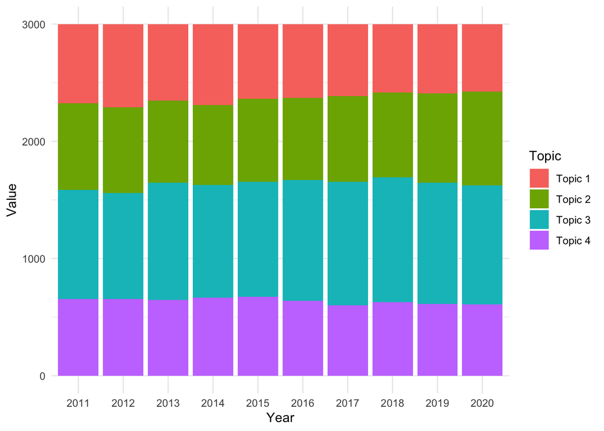

```r
years_to_keep <- c(2011:2020)
selected_freq_table <- freq_table[rownames(freq_table) %in% years_to_keep, ]
selected_freq_data = as.data.frame(selected_freq_table)

melted_data <- melt(selected_freq_table, id.vars = "year")

# Plot counts between 2011 and 2020
ggplot(melted_data, aes(x = factor(Var1), y = value, fill = factor(Var2))) +
  geom_bar(stat = "identity") +
  labs(x = "Year", y = "Value", fill = "Category") +
  scale_fill_discrete(name = "Topic", labels = c("Topic 1", "Topic 2", "Topic 3", "Topic 4")) +
  theme_minimal() +
  theme(legend.position = "right")
```

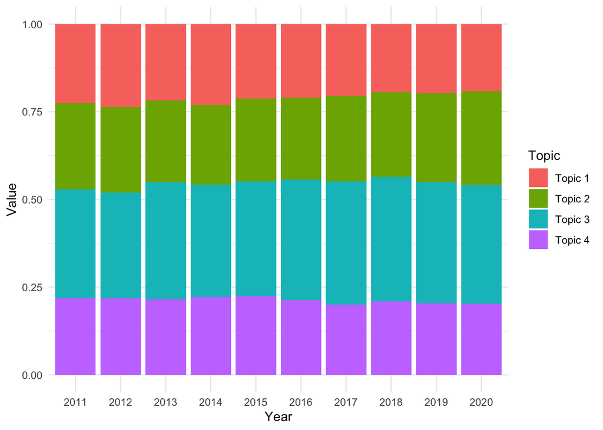

```r
# Frequencies
frequencies = melted_data
frequencies$value = frequencies$value / 3000

# Plot frequencies
ggplot(frequencies, aes(x = factor(Var1), y = value, fill = factor(Var2))) +
  geom_bar(stat = "identity") +
  labs(x = "Year", y = "Value", fill = "Category") +
  scale_fill_discrete(name = "Topic", labels = c("Topic 1", "Topic 2", "Topic 3", "Topic 4")) +
  theme_minimal() +
  theme(legend.position = "right")
```

The frequency of the topics appears to change throughout the years. In order to quantitavely assess whether there is a significant change in the frequencies, we decided to perform Two-sample T tests.

## Two-Sample t-Tests

Two-sample t-Test calculates whether the difference between two groups is significant or not. In our case, we grouped our data into two: Before 2020 and Year 2020. To be able compare two groups, we assumed that topic counts comes from the same distribution within 2011 and 2019. Hence, we calculated sample mean for the group ‘Before 2020’ and prepared frequencies for Year 2020, as well.

```r
# Previous means vs 2020
selected_freq_data$Var1 = as.numeric(selected_freq_data$Var1)
selected_freq_data$Var1 = selected_freq_data$Var1 + 2010

# Means of previous years
means_df <- selected_freq_data %>%
  filter(Var1 >= 2011 & Var1 <= 2019) %>%
  group_by(Var2) %>%
  summarise(mean_value = mean(Freq))

# Count of 2020
means_2020= selected_freq_data %>%
  filter(Var1 == 2020) %>%
  group_by(Var2) %>%
  summarise(mean_value = mean(Freq))
```

Our null hypothesis and alternative hypothesis are:

- H0: The mean frequency of Topic X of group ‘Before 2020’ is equal to the mean frequency of Topic X of group ‘Year 2020’.
- H1: The mean frequency of Topic X of group ‘Before 2020’ is not equal to the mean frequency of Topic X of group ‘Year 2020’.

where X is any topic.

Since we are planning to perform multiple t-Tests, we applied Bonferroni correction to prevent any erroneous significant findings.

```r
significance_level = 0.05 /4

# Perform the two-sample t-test
for (i in 1:4) {
  result <- t.test(c(means_df$mean_value[i], means_2020$mean_value[i]), c(3000, 3000),
                      correct = FALSE, alpha = significance_level)
  # Bonferroni correction
  p_value = result$p.value
  print(p_value < significance_level)
}
```

```
## [1] TRUE
## [1] TRUE
## [1] TRUE
## [1] TRUE
```

With significance level of 0.05 and Bonferroni correction, the test results indicates that the means of all topics of group ‘Year 2020’ are significantly different than the means of topics of group ‘Before 2020’. We can claim that there are indeed a difference between the year 2020 and the previous years. Even though further research is needed, this finding supports the hyptohesis which claims that COVID-19 have an effect on the topic frequency of the ‘Depression’ Subreddit posts in English.

To answer our third subquestion, we selected only the data from 2020 and plotted the number of topics per month.

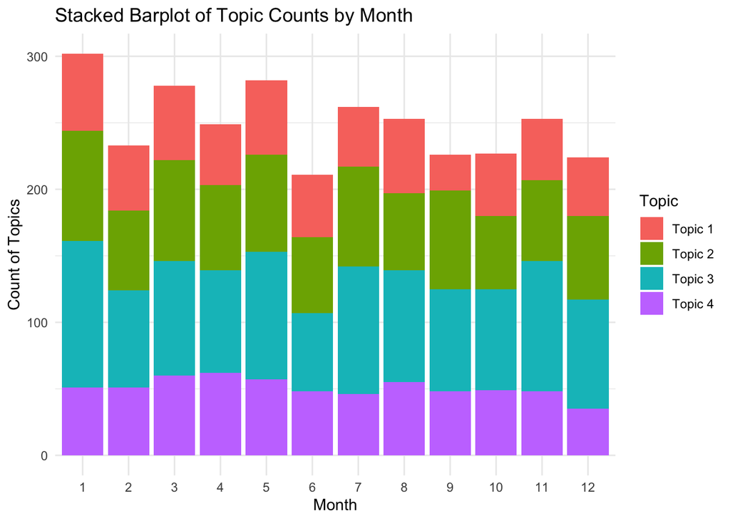

```r
df_2020 = df %>% filter(year == 2020) %>%
  mutate(month = month(date))

# Create the stacked barplot - Count
ggplot(df_2020, aes(x = factor(month), fill = factor(topics))) +
  geom_bar(position = "stack") +
  labs(x = "Month", y = "Count of Topics", title = "Stacked Barplot of Topic Counts by Month") +
  scale_fill_discrete(name = "Topic", labels = c("Topic 1", "Topic 2", "Topic 3", "Topic 4")) +
  theme_minimal()
```

It appears that the number of texts changes from month to month, thus, we calculated the relative frequencies and plotted again to be able to compare different months.

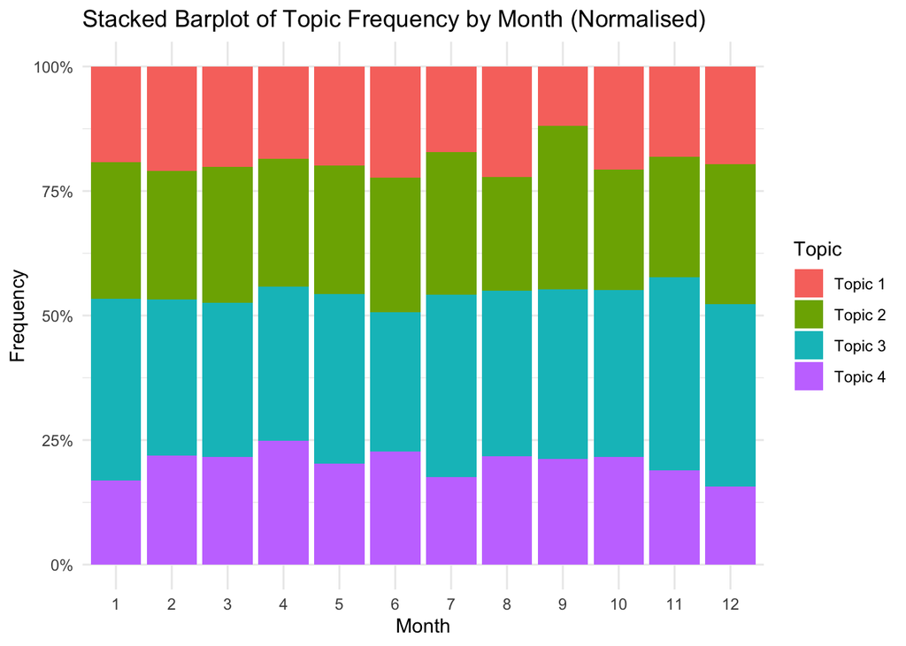

```r
# Create the stacked barplot - Frequency
ggplot(df_2020, aes(x = factor(month), fill = factor(topics))) +
  geom_bar(position = "fill") +
  labs(x = "Month", y = "Frequency", title = "Stacked Barplot of Topic Frequency by Month (Normalised)") +
  scale_y_continuous(labels = scales::percent, limits = c(0, 1)) +
  scale_fill_discrete(name = "Topic", labels = c("Topic 1", "Topic 2", "Topic 3", "Topic 4")) +
  theme_minimal()
```

It appears that there are some deviations within the data in terms of frequencies over the months. To assess it quantitatively, we again planned to apply two-sample t-Tests. Since we are interested in whether the frequency of topics changed during 2020, we compared each month’s topic frequencies with the overall topic frequencies of the year.

```r
summarized_data <- df_2020 %>%
  group_by(month, topics) %>%
  summarize(count = n())

reshaped_data <- summarized_data %>%
  pivot_wider(names_from = month, values_from = count, values_fill = 0)

reshaped_data$mean <- rowMeans(reshaped_data[, -1])
```

Our null hypothesis and alternative hypothesis are:

- H0: The mean frequency of Topic X of group Month Y in 2020 is equal to the mean frequency of Topic X of the mean frequency of Topic X in 2020.
- H0: The mean frequency of Topic X of group Month Y in 2020 is not equal to the mean frequency of Topic X of the mean frequency of Topic X in 2020.

where X is any topic and Y is any month.

For each month, we applied two-sample t-Test and Bonferroni correction for each frequency. Since we did 48 comparison, the correction rate is 48.

```r
significance_level = 0.05 / 48
print(significance_level)
```

```
## [1] 0.001041667
```

```r
for (i in 1:4) {
  result <- t.test(c(reshaped_data$'mean'[i], reshaped_data$'1'[i]), c(250, sum(reshaped_data$'1')),
                   correct = FALSE, alpha = significance_level)
  p_value = result$p.value
  print(p_value)
  print(p_value < significance_level)}
```

```
## [1] 0.06541082
## [1] FALSE
## [1] 0.06061048
## [1] FALSE
## [1] 0.05131017
## [1] FALSE
## [1] 0.07321064
## [1] FALSE
```

With significance level of 0.05 and Bonferroni correction, the adjusted significance level is 0.001041667. There is not enough evidence to reject the null hypothesis, in other words, the means of topics of January are not significantly different than the overall 2020 topic means.

```r
significance_level = 0.05 / 48
print(significance_level)
```

```
## [1] 0.001041667
```

```r
for (i in 1:4) {
  result <- t.test(c(reshaped_data$'mean'[i], reshaped_data$'2'[i]), c(250, sum(reshaped_data$'2')),
                   correct = FALSE, alpha = significance_level)
  p_value = result$p.value
  print(p_value)
  print(p_value < significance_level)}
```

```
## [1] 0.02759255
## [1] FALSE
## [1] 0.01477243
## [1] FALSE
## [1] 0.006679832
## [1] FALSE
## [1] 0.02835983
## [1] FALSE
```

With significance level of 0.05 and Bonferroni correction, the adjusted significance level is 0.001041667. There is not enough evidence to reject the null hypothesis, in other words, the means of topics of February are not significantly different than the overall 2020 topic means.

```r
significance_level = 0.05 / 48
print(significance_level)
```

```
## [1] 0.001041667
```

```r
for (i in 1:4) {
  result <- t.test(c(reshaped_data$'mean'[i], reshaped_data$'3'[i]), c(250, sum(reshaped_data$'3')),
                   correct = FALSE, alpha = significance_level)
  p_value = result$p.value
  print(p_value)
  print(p_value < significance_level)}
```

```
## [1] 0.02961714
## [1] FALSE
## [1] 0.02907229
## [1] FALSE
## [1] 0.04916162
## [1] FALSE
## [1] 0.02702466
## [1] FALSE
```

With significance level of 0.05 and Bonferroni correction, the adjusted significance level is 0.001041667. There is not enough evidence to reject the null hypothesis, in other words, the means of topics of March are not significantly different than the overall 2020 topic means.

```r
significance_level = 0.05 / 48
print(significance_level)
```

```
## [1] 0.001041667
```

```r
for (i in 1:4) {
  result <- t.test(c(reshaped_data$'mean'[i], reshaped_data$'4'[i]), c(250, sum(reshaped_data$'4')),
                   correct = FALSE, alpha = significance_level)
  p_value = result$p.value
  print(p_value)
  print(p_value < significance_level)}
```

```
## [1] 0.0004364267
## [1] TRUE
## [1] 0.001240574
## [1] FALSE
## [1] 0.01255898
## [1] FALSE
## [1] 0.01751328
## [1] FALSE
```

With significance level of 0.05 and Bonferroni correction, the adjusted significance level is 0.001041667. The test suggests that there is enough evidence to reject the null hypothesis for topic 1 which has the p-value of 0.000436.In other words, the mean frequency of topic 1 of April is significantly different than the overall 2020 topic 1 mean frequency.

```r
significance_level = 0.05 / 48
print(significance_level)
```

```
## [1] 0.001041667
```

```r
for (i in 1:4) {
  result <- t.test(c(reshaped_data$'mean'[i], reshaped_data$'5'[i]), c(250, sum(reshaped_data$'5')),
                   correct = FALSE, alpha = significance_level)
  p_value = result$p.value
  print(p_value)
  print(p_value < significance_level)}
```

```
## [1] 0.03681556
## [1] FALSE
## [1] 0.04401568
## [1] FALSE
## [1] 0.03627646
## [1] FALSE
## [1] 0.04099837
## [1] FALSE
```

With significance level of 0.05 and Bonferroni correction, the adjusted significance level is 0.001041667. There is not enough evidence to reject the null hypothesis, in other words, the means of topics of May are not significantly different than the overall 2020 topic means.

```r
significance_level = 0.05 / 48
print(significance_level)
```

```
## [1] 0.001041667
```

```r
for (i in 1:4) {
  result <- t.test(c(reshaped_data$'mean'[i], reshaped_data$'6'[i]), c(250, sum(reshaped_data$'6')),
                   correct = FALSE, alpha = significance_level)
  p_value = result$p.value
  print(p_value)
  print(p_value < significance_level)}
```

```
## [1] 0.06740877
## [1] FALSE
## [1] 0.05995417
## [1] FALSE
## [1] 0.03028313
## [1] FALSE
## [1] 0.06701304
## [1] FALSE
```

With significance level of 0.05 and Bonferroni correction, the adjusted significance level is 0.001041667. There is not enough evidence to reject the null hypothesis, in other words, the means of topics of June are not significantly different than the overall 2020 topic means.

```r
significance_level = 0.05 / 48
print(significance_level)
```

```
## [1] 0.001041667
```

```r
for (i in 1:4) {
  result <- t.test(c(reshaped_data$'mean'[i], reshaped_data$'7'[i]), c(250, sum(reshaped_data$'7')),
                   correct = FALSE, alpha = significance_level)
  p_value = result$p.value
  print(p_value)
  print(p_value < significance_level)}
```

```
## [1] 0.01222056
## [1] FALSE
## [1] 0.002689067
## [1] FALSE
## [1] 0.00252568
## [1] FALSE
## [1] 0.007258235
## [1] FALSE
```

With significance level of 0.05 and Bonferroni correction, the adjusted significance level is 0.001041667. There is not enough evidence to reject the null hypothesis, in other words, the means of topics of July are not significantly different than the overall 2020 topic means.

```r
significance_level = 0.05 / 48
print(significance_level)
```

```
## [1] 0.001041667
```

```r
for (i in 1:4) {
  result <- t.test(c(reshaped_data$'mean'[i], reshaped_data$'8'[i]), c(250, sum(reshaped_data$'8')),
                   correct = FALSE, alpha = significance_level)
  p_value = result$p.value
  print(p_value)
  print(p_value < significance_level)}
```

```
## [1] 0.00494297
## [1] FALSE
## [1] 0.006648711
## [1] FALSE
## [1] 0.004511526
## [1] FALSE
## [1] 0.0003301493
## [1] TRUE
```

With significance level of 0.05 and Bonferroni correction, the adjusted significance level is 0.001041667. The test suggests that there is enough evidence to reject the null hypothesis for topic 4 which has the p-value of 0.00033. In other words, the mean frequency of topic 4 of August is significantly different than the overall 2020 topic 4 mean frequency.

```r
significance_level = 0.05 / 48
print(significance_level)
```

```
## [1] 0.001041667
```

```r
for (i in 1:4) {
  result <- t.test(c(reshaped_data$'mean'[i], reshaped_data$'9'[i]), c(250, sum(reshaped_data$'9')),
                   correct = FALSE, alpha = significance_level)
  p_value = result$p.value
  print(p_value)
  print(p_value < significance_level)}
```

```
## [1] 0.006690064
## [1] FALSE
## [1] 0.03054427
## [1] FALSE
## [1] 0.03269511
## [1] FALSE
## [1] 0.03794272
## [1] FALSE
```

With significance level of 0.05 and Bonferroni correction, the adjusted significance level is 0.001041667. There is not enough evidence to reject the null hypothesis, in other words, the means of topics of September are not significantly different than the overall 2020 topic means.

```r
significance_level = 0.05 / 48
print(significance_level)
```

```
## [1] 0.001041667
```

```r
for (i in 1:4) {
  result <- t.test(c(reshaped_data$'mean'[i], reshaped_data$'10'[i]), c(250, sum(reshaped_data$'10')),
                   correct = FALSE, alpha = significance_level)
  p_value = result$p.value
  print(p_value)
  print(p_value < significance_level)}
```

```
## [1] 0.03789248
## [1] FALSE
## [1] 0.01541014
## [1] FALSE
## [1] 0.02666325
## [1] FALSE
## [1] 0.03763264
## [1] FALSE
```

With significance level of 0.05 and Bonferroni correction, the adjusted significance level is 0.001041667. There is not enough evidence to reject the null hypothesis, in other words, the means of topics of October are not significantly different than the overall 2020 topic means.

```r
significance_level = 0.05 / 48
print(significance_level)
```

```
## [1] 0.001041667
```

```r
for (i in 1:4) {
  result <- t.test(c(reshaped_data$'mean'[i], reshaped_data$'11'[i]), c(250, sum(reshaped_data$'11')),
                   correct = FALSE, alpha = significance_level)
  p_value = result$p.value
  print(p_value)
  print(p_value < significance_level)}
```

```
## [1] 0.0001946359
## [1] TRUE
## [1] 0.001468417
## [1] FALSE
## [1] 0.02059111
## [1] FALSE
## [1] 0.000106922
## [1] TRUE
```

With significance level of 0.05 and Bonferroni correction, the adjusted significance level is 0.001041667. The test suggests that there is enough evidence to reject the null hypothesis for topic 1 and topic 4. In other words, the mean frequencies of topic 1 and topic 4 of November are significantly different than the overall 2020 topic frequencies of topic 1 and topic 4.

```r
significance_level = 0.05 / 48
print(significance_level)
```

```
## [1] 0.001041667
```

```r
for (i in 1:4) {
  result <- t.test(c(reshaped_data$'mean'[i], reshaped_data$'12'[i]), c(250, sum(reshaped_data$'12')),
                   correct = FALSE, alpha = significance_level)
  p_value = result$p.value
  print(p_value)
  print(p_value < significance_level)}
```

```
## [1] 0.03878192
## [1] FALSE
## [1] 0.044247
## [1] FALSE
## [1] 0.05172784
## [1] FALSE
## [1] 0.01205856
## [1] FALSE
```

With significance level of 0.05 and Bonferroni correction, the adjusted significance level is 0.001041667. There is not enough evidence to reject the null hypothesis, in other words, the means of topics of December are not significantly different than the overall 2020 topic means.

# Discussion

The original goal of this notebook was to analyze whether COVID-19 had any effect on the topics of Depression Subreddit Posts. To do so, we used a pre-existing dataset containing around 33000 Reddit posts on Depression subreddit that were collected using web scraping. We cleaned the data and applied unsupervised learning algorithm Latent Dirichlet Allocation (LDA) to perform topic modelling. First, we calculated coherence scores to find the best number of topics in our data, which was one of our sub questions and determined it as 4. After determining the number of topics, we fitted our model into the data and predicted the topics of each Reddit post.

To answer other research interests, we compared the topic frequencies of Year 2020 and Years before 2020. We found that the count/frequency of each topic of Year 2020 is significantly different than the Years before 2020.

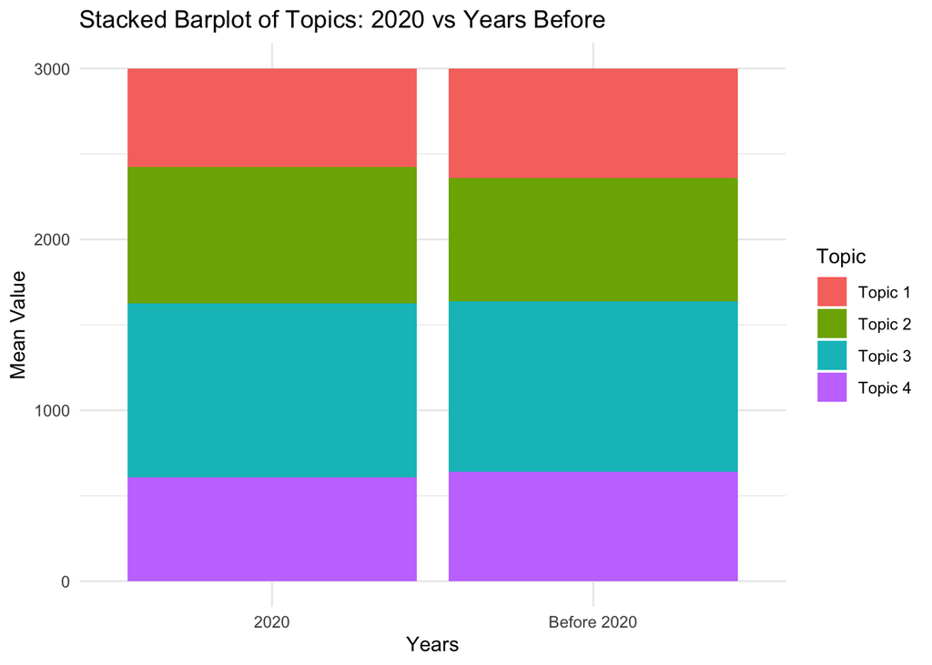

```r
# Plot for discussion: Counts of topics before 2020 vs 2020
cd <- rbind(
  mutate(means_df, source = "Before 2020"),
  mutate(means_2020, source = "2020")
)

# Create a ggplot stacked bar plot
ggplot(cd, aes(x = source, y = mean_value, fill = factor(Var2))) +
  geom_bar(stat = "identity") +
  labs(x = "Years", y = "Mean Value", fill = "Var2", title = "Stacked Barplot of Topics: 2020 vs Years Before") +
  scale_fill_discrete(name = "Topic", labels = c("Topic 1", "Topic 2", "Topic 3", "Topic 4")) +
  theme_minimal()
```

We also wanted to the test whether there is a difference between the months of 2020, during the pandemic. We have found that the frequencies of Topic 1 in April, Topic 4 in August, and Topic 1 and Topic 4 in November are significantly different than the overall frequency of topics in 2020. However, since there is no clear pattern, the significant results might be explained by the sampling variance - considering we do not have large sample size per month.

As a result, in this study we concluded that the English posts in Depression subreddit can be classified into 4 different groups. Their distributions have changes significantly after the pandemic have started - especially the topics that contains the words ‘feeling’, ‘depressed’, ‘talk’, ‘home’, and ‘friend’- but the distributions remained more or less the same within 2020. However, it is important to note that this work suffers from some important limitations, hence, these results need to be taken with a grain of salt. Some of these limitations have already been briefly hinted at but we now provide a more thorough review of them.

# Limitations

**Data Size:** The dataset comprise solely 3000 posts per annum from the depression subreddit. The precise criteria for post selection for the dataset remain unspecified hence the dataset might not be representative of the all posts in depression subreddit.

**Distribution Assumption:** As we averaged the topic numbers for the years before 2020 and the year 2020 itself, we assumed that the topics follow a Gaussian distribution before 2020 and also follow a Gaussian distribution in 2020. T-Test also have the same assumptions. Any deviation from this assumption means that the findings are meaningless.

**Generalisation and Representative:** It is heavily important that claim neither our results are representative of other online mediums nor the online mediums. There are other websites and subreddits within Reddit that contains similar texts/posts that we did not include.

**Stemming** The presence of both stemmed and non-stemmed versions of certain words, particularly irregular verbs (e.g., “feel” and “felt”), introduces a potential source of ambiguity and could potentially undermine the model’s performance and subsequent results.

**Place Holder** The inclusion of the placeholder string “place_holder_for_analysis” as a workaround to resolve an issue during algorithm execution may introduce an artificial element into the dataset, potentially impacting model performance. However, it is important to note that when the algorithm was run in Python, we have not encountered any problem.

# References

Blei, D. M., Ng, A. Y., & Jordan, M. I. (2003). Latent Dirichlet allocation. Journal of Machine Learning Research, 3, 993-1022.

Brown, A., Rice, S. M., Rickwood, D. J., & Parker, A. G. (2016). Systematic review of barriers and facilitators to accessing and engaging with mental health care among at-risk young people. Asia Pacific Psychiatry, 8(1), 3-22.

Bruce, M. L., Seeman, T. E., Merrill, S. S., & Blazer, D. G. (1994). The impact of depressive symptomatology on physical disability: MacArthur Studies of Successful Aging. American Journal of Public Health, 84, 1796-1799.

De Choudhury, M., & De, S. (2014). Mental health discourse on Reddit: Self-disclosure, social support, and anonymity. Proceedings of the International AAAI Conference on Web and Social Media, 8(1), 71-80. https://doi.org/10.1609/icwsm.v8i1.14526

Fiorillo, A., & Gorwood, P. (2020). The consequences of the COVID-19 pandemic on mental health and implications for clinical practice. European Psychiatry, 63, e32.

Lynch, F. L., Peterson, E. L., Lu, C. Y., et al. (2020). Substance use disorders and risk of suicide in a general US population: A case-control study. Addictive Science & Clinical Practice, 15, 14. https://doi.org/10.1186/s13722-020-0181-1

Low, D., Rumker, L., Talkar, T., Torous, J., Cecchi, G., & Ghosh, S. (2020). Natural Language Processing Reveals Vulnerable Mental Health Support Groups and Heightened Health Anxiety on Reddit During COVID-19: Observational Study. Journal of Medical Internet Research, 22(10), e22635. https://doi.org/10.2196/22635

Erik, M. (2012). “blog.reddit – what’s new on reddit: 2 Billion & Beyond”. Redditblog.com.

Mathers, C. D., & Loncar, D. (2006). Projections of global mortality and burden of disease from 2002 to 2030. PLoS Medicine, 3, e442. doi:10.1371/journal.pmed.0030442

Matos, L. F. (2021). English depression-related posts from Reddit. Retrieved August 10, 2023, from https://www.kaggle.com/datasets/luizfmatos/reddit-english-depression-related-submissions

Prince, M. J., Harwood, R. H., Thomas, A., & Mann, A. H. (1998). A prospective population-based cohort study of the effects of disablement and social milieu on the onset and maintenance of late-life depression: The Gospel Oak Project VII. Psychological Medicine, 28, 337-350.

Prince, M., Patel, V., Saxena, S., Maj, M., Maselko, J., Phillips, M. R., & Rahman, A. (2007). No health without mental health. The Lancet, 370(9590), 859-877. doi:10.1016/S0140-6736(07)61238-0

Purssell, E., Gould, D., & Chudleigh, J. (2020). Impact of isolation on hospitalized patients who are infectious: Systematic review with meta-analysis. BMJ Open, 10, e030371.

WHO. (2005). Mental health: Facing the challenges, building solutions. Report from the WHO European Ministerial Conference. WHO Regional Office for Europe, Copenhagen, Denmark.

WHO. (2020, March 6). Coronavirus disease (COVID-19) pandemic. WHO emergencies. Retrieved from https://www.who.int/emergencies/diseases/novel-coronavirus-2019/situation-reports

# Appendix

## Python Script

```r
# import pandas as pd
# import json
# from datetime import datetime
# import numpy as np
# import matplotlib.pyplot as plt
# import contractions
# import re
# %matplotlib inline
# import seaborn as sns
# plt.style.use("fivethirtyeight")
# pd.set_option('display.max_colwidth', 80)
# import matplotlib.patheffects as path_effects
# import nltk
# import gensim
# from nltk.corpus import stopwords
# from nltk.stem import WordNetLemmatizer
# from collections import Counter
# from wordcloud import WordCloud, STOPWORDS, ImageColorGenerator
#
# nltk.download('stopwords')
# nltk.download('wordnet')
# nltk.download('omw-1.4')
# nltk.download('averaged_perceptron_tagger')
#
# json_path = '/Users/Serkan/Downloads/_reddit-posts-gatherer-en.submissions_subset.json'
# f = open(json_path)
# all_data = json.load(f)
# f.close()
#
# class post:
#     def __init__(self, json_file):
#         self.date = datetime.strptime(json_file['date'], '%Y-%m-%d %H:%M:%S')
#         self.is_text_only = json_file['is_text_only']
#         self.title = json_file['title']
#         self.text = json_file['body']
#         self.url = json_file['url']
#
# class multiple_posts:
#     def __init__(self):
#         self.data = np.array([0,0,0]).reshape(1,3)
#
#     def add(self, post_obj):
#         date = datetime(post_obj.date.year, post_obj.date.month, 1)
#         self.data = np.append(self.data, np.array([date, post_obj.title, post_obj.text]).reshape(1,3), axis = 0)
#
#     def remove_place_holder(self):
#         self.data = self.data[1:]
#
#     def sort_by_date(self):
#         index = np.argsort(self.data[:,0])
#         self.data = self.data[index]
#
# data = multiple_posts()
# for item in all_data:
#     data.add(post(item))
# data.remove_place_holder()
# data.sort_by_date()
# df = pd.DataFrame(data.data, columns=['Date', 'Title', 'Text'])
# df = df.dropna()
# df['Year'] = df['Date'].dt.year
#
# df.to_json(r'/Users/Serkan/Downloads/reddit_data_updated.json')
#
# def text_preprocessing(text):
#
#     # Convert words to lower case
#     text = text.lower()
#
#     # Expand contractions
#     if True:
#         text = text.split()
#         new_text = []
#         for word in text:
#             new_text.append(contractions.fix(word))
#         text = " ".join(new_text)
#
#     # Format words and remove unwanted characters
#     text = re.sub(r'https?:\/\/.*[\r\n]*', '', text, flags=re.MULTILINE)
#     text = re.sub(r'\<a href', ' ', text)
#     text = re.sub(r'&amp;', '', text)
#     text = re.sub(r'[_"\-;%()|+&=*%.,!?:#$@\[\]/]', ' ', text)
#     text = re.sub(r'<br />', ' ', text)
#     text = re.sub(r'\'', ' ', text)
#
#     # Tokenize each word
#     text = nltk.WordPunctTokenizer().tokenize(text)
#
#     # Lemmatize each word
#     text = [nltk.stem.WordNetLemmatizer().lemmatize(token, pos='v') for token in text if len(token)>1]
#
#     return text
#
# def to_string(text):
#     # Convert list to string
#     text = ' '.join(map(str, text))
#
#     return text
#
# # Create a list of review by applying text_preprocessing function
# df['text_clean_list'] = list(map(text_preprocessing, df.Text))
#
# # Return to string with to_string function
# df['text_clean'] = list(map(to_string, df['text_clean_list']))
#
# # Join all word corpus
# df_words = ','.join(list(df['text_clean'].values))
#
# # Count and find the 30 most frequent
# counter = Counter(df_words.split())
# most_frequent = counter.most_common(50)
#
# # Bar plot of frequent words
# fig = plt.figure(1, figsize = (20,10))
# _ = pd.DataFrame(most_frequent, columns=("words","count"))
# sns.barplot(x = 'words', y = 'count', data = _, palette = 'winter')
# plt.title('50 Most Frequent Words')
# plt.xticks(rotation=45)
# # plt.savefig('Count.png')
#
# # Load the list of stopwords
#
# stopwords_list = stopwords.words('english')
# stopwords_list.extend(['can', 'friends', 'got', 'just', 'know', 'like', 'think', 'want', 'even',
#                     'feel', 'going', 'life', 'make', 'people', 'still', 'time', 'one', 'work', 'back',
#                     'better', 'day', 'depression', 'get', 'good', 'much', 'never', 'now', 'really',
#                     'school', 'something', 'things', 'way', 'will', 'help', 'see', 'someone', 'years',
#                     'always', 'everything', 'year'])
#
#
# df['text_clean_list'] = [[word for word in line if word not in stopwords_list] for line in df['text_clean_list']]
# df['text_clean'] = list(map(to_string, df['text_clean_list']))
#
# # Join all word corpus
# df_words = ','.join(list(df['text_clean'].values))
#
# # Count and find the 30 most frequent
# counter = Counter(df_words.split())
# most_frequent = counter.most_common(30)
#
# # Bar plot of frequent words
# fig = plt.figure(1, figsize = (20,10))
# _ = pd.DataFrame(most_frequent, columns=("words","count"))
# sns.barplot(x = 'words', y = 'count', data = _, palette = 'winter')
# plt.xticks(rotation=45);
#
# # Create Dictionary
# id2word = gensim.corpora.Dictionary(df['text_clean_list'])
#
# # Create Corpus: Term Document Frequency
# corpus = [id2word.doc2bow(text) for text in df['text_clean_list']]
#
# # Compute Coherence Score
# number_of_topics = []
# coherence_score = []
# for i in range(1,10):
#   lda_model = gensim.models.ldamodel.LdaModel(corpus=corpus,
#                                               id2word=id2word,
#                                               iterations=50,
#                                               num_topics=i)
#   coherence_model_lda = CoherenceModel(model=lda_model, texts=df['text_clean_list'], dictionary=id2word, coherence='c_v')
#   coherence_lda = coherence_model_lda.get_coherence()
#   number_of_topics.append(i)
#   coherence_score.append(coherence_lda);
#
# # Create a dataframe of coherence score by number of topics
# topic_coherence = pd.DataFrame({'number_of_topics':number_of_topics,
#                                 'coherence_score':coherence_score})
#
# # Print a line plot
# sns.lineplot(data=topic_coherence, x='number_of_topics', y='coherence_score')
```